# Day_4 slides

## Introduction to

[figure not shown]

### with Application to Bioinformatics

#### - Day 4

### TODAY

- Keyword arguments
- Loops with break and continue
- "Code structure": comments and documentation
- Importing modules: using libraries
- Pandas - explore your data!

#### Review

- In what ways does the type of an object matter? Explain the output of:

```python
row = 'sofa|2000|buy|Uppsala'
fields = row.split('|')
price = fields[1]
if price == 2000:
    print('The price is a number!')
if price == '2000':
    print('The price is a string!')
```

```
The price is a string!
```

```python
print(sorted([ 2000,   30,   100 ]))
print(sorted(['2000', '30', '100']))
# Hint: is `'30' > '2000'`?
```

```
[30, 100, 2000]
['100', '2000', '30']
```

- How can you convert an object to a different type?
  - Convert to number: `'2000'` and `'0.5'` and `'1e9'`
  - Convert to boolean: `1`, `0`, `'1'`, `'0'`, `''`, `{}`
- We have seen these container types: **lists**, **sets**, **dictionaries**. What is their difference and when should you use which?
- What is a function? Write a function that counts the number of occurrences of `'C'` in the argument string.

#### In what ways does the type of an object matter?

```python
row = 'sofa|2000|buy|Uppsala'
fields = row.split('|')
price = int(fields[1])
if price == 2000:
    print('The price is a number!')
if price == '2000':
    print('The price is a string!')
```

```
The price is a number!
```

```python
print(sorted([ 2000,   30,   100 ]))
print(sorted(['2000', '30', '100']))
# Hint: is `'30' > '2000'`?
```

```
[30, 100, 2000]
['100', '2000', '30']
```

#### In what ways does the type of an object matter?

- Each type store a specific type of information
  - `int` for integers,
  - `float` for floating point values (decimals),
  - `str` for strings,
  - `list` for lists,
  - `dict` for dictionaries.
- Each type supports different operations, functions and methods.
- Each type supports different **operations**, functions and methods

```python
30 > 2000
```

```
False
```

```python
'30' > '2000'
```

```
True
```

```python
30 > int('2000')
```

```
False
```

- Each type supports different operations, functions and **methods**

```python
'ACTG'.lower()
```

```
'actg'
```

```python
[1, 2, 3].lower()
```

```
---------------------------------------------------------------------------
AttributeError                            Traceback (most recent call last)
<ipython-input-10-4e1a84c0439c> in <module>
----> 1 [1, 2, 3].lower()

AttributeError: 'list' object has no attribute 'lower'
```

- Convert to number: `'2000'` and `'0.5'` and `'1e9'`

```python
int('2000')
```

```
2000
```

```python
int('0.5')
```

```
---------------------------------------------------------------------------
ValueError                                Traceback (most recent call last)
<ipython-input-12-6d0b04c882d1> in <module>
----> 1 int('0.5')

ValueError: invalid literal for int() with base 10: '0.5'
```

```python
int('1e9')
```

```
---------------------------------------------------------------------------
ValueError                                Traceback (most recent call last)
<ipython-input-13-cb568d180cc9> in <module>
----> 1 int('1e9')

ValueError: invalid literal for int() with base 10: '1e9'
```

```python
float('2000')
```

```
2000.0
```

```python
int(float('1.5'))
```

```
1
```

```python
int(float('1e9'))
```

```
1000000000
```

- Convert to boolean: `1`, `0`, `'1'`, `'0'`, `''`, `{}`

```python
bool(1)
```

```
True
```

```python
bool(0)
```

```
False
```

```python
bool('1')
```

```
True
```

```python
bool('0')
```

```
True
```

```python
bool('')
```

```
False
```

```python
bool({})
```

```
False
```

- Python and the truth: true and false values

```python
values = [1, 0, '', '0', '1', [], [0]]
for x in values:
    if x:
        print(repr(x), 'is true!')
    else:
        print(repr(x), 'is false!')
```

```
1 is true!
0 is false!
'' is false!
'0' is true!
'1' is true!
[] is false!
[0] is true!
```

- Converting between strings and lists

```python
list("hello")
```

```
['h', 'e', 'l', 'l', 'o']
```

```python
str(['h', 'e', 'l', 'l', 'o'])
```

```
"['h', 'e', 'l', 'l', 'o']"
```

```python
'_'.join(['h', 'e', 'l', 'l', 'o'])
```

```
'h_e_l_l_o'
```

#### Container types, when should you use which?

- **lists**: when order is important
- **dictionaries**: to keep track of the relation between keys and values
- **sets**: to check for membership. No order, no duplicates.

```python
genre_list = ["comedy", "drama", "drama", "sci-fi"]
genre_list
```

```
['comedy', 'drama', 'drama', 'sci-fi']
```

```python
genres = set(genre_list)
'drama' in genres
```

```
True
```

```python
genre_counts = {"comedy": 1, "drama": 2, "sci-fi": 1}
genre_counts
```

```
{'comedy': 1, 'drama': 2, 'sci-fi': 1}
```

```python
movie = {"rating": 10.0, "title": "Toy Story"}
movie
```

```
{'rating': 10.0, 'title': 'Toy Story'}
```

#### What is a function?

- A named piece of code that performs a specific task
- A relation (mapping) between inputs (arguments) and output (return value)
- Write a function that counts the number of occurences of `'C'` in the argument string.
- Function for counting the number of occurences of `'C'`

```python
def cytosine_count(nucleotides):
    count = 0
    for x in nucleotides:
        if x == 'c' or x == 'C':
            count += 1
    return count

count1 = cytosine_count('CATATTAC')
count2 = cytosine_count('tagtag')
print(count1, count2)
```

```
2 0
```

- Functions that `return` are easier to repurpose than those that `print` their result

```python
cytosine_count('catattac') + cytosine_count('tactactac')
```

```
5
```

```python
def print_cytosine_count(nucleotides):
    count = 0
    for x in nucleotides:
        if x == 'c' or x == 'C':
            count += 1
    print(count)

print_cytosine_count('catattac') + print_cytosine_count('tactactac')
```

```
2
3
```

```
---------------------------------------------------------------------------
TypeError                                 Traceback (most recent call last)
<ipython-input-33-5bbd47c30b94> in <module>
      6     print(count)
      7
----> 8 print_cytosine_count('catattac') + print_cytosine_count('tactactac')

TypeError: unsupported operand type(s) for +: 'NoneType' and 'NoneType'
```

- Objects and references to objects

```python
list_A = ['red', 'green']
list_B = ['red', 'green']
list_B.append('blue')
print(list_A, list_B)
```

```
['red', 'green'] ['red', 'green', 'blue']
```

```python
list_A = ['red', 'green']
list_B = list_A            # another name to the SAME list. Aliasing
list_B.append('blue')
print(list_A, list_B)
```

```
['red', 'green', 'blue'] ['red', 'green', 'blue']
```

```python
list_A = ['red', 'green']
list_B = list_A
list_A = []
print(list_A, list_B)
```

```
[] ['red', 'green']
```

- Objects and references to objects, cont.

```python
list_A = ['red', 'green']
lists = {'A': list_A, 'B': list_A}
print(lists)
lists['B'].append('blue')
print(lists)
```

```
{'A': ['red', 'green'], 'B': ['red', 'green']}
{'A': ['red', 'green', 'blue'], 'B': ['red', 'green', 'blue']}
```

```python
list_A = ['red', 'green']
lists = {'A': list_A, 'B': list_A}
print(lists)
lists['B'] = lists['B'] + ['yellow']
print(lists)
```

```
{'A': ['red', 'green'], 'B': ['red', 'green']}
{'A': ['red', 'green'], 'B': ['red', 'green', 'yellow']}
```

#### Scope: global variables and local function variables

```python
movies = ['Toy story', 'Home alone']
```

```python
def some_thriller_movies():
    return ['Fargo', 'The Usual Suspects']

movies = some_thriller_movies()
print(movies)
```

```
['Fargo', 'The Usual Suspects']
```

```python
def change_to_drama(movies):
    movies = ['Forrest Gump', 'Titanic']

change_to_drama(movies)
print(movies)
```

```
['Fargo', 'The Usual Suspects']
```

```python
def change_to_scifi(movies):
    movies.clear()
    movies += ['Terminator II', 'The Matrix']

change_to_scifi(movies)
print(movies)
```

```
['Terminator II', 'The Matrix']
```

#### Keyword arguments

- A way to give a name explicitly to a function for clarity

```python
sorted(list('file'), reverse=True)
```

```
['l', 'i', 'f', 'e']
```

```python
attribute = 'gene_id "unknown gene"'
attribute.split(sep=' ', maxsplit=1)
```

```
['gene_id', '"unknown gene"']
```

```python
# print(value, ..., sep=' ', end='\n', file=sys.stdout, flush=False)
print('x=', end='')
print('1')
```

```
x=1
```

#### Keyword arguments

- Order of keyword arguments do not matter

```
open(file, mode='r', encoding=None) # some arguments omitted
```

- These mean the same:

```
open('files/recipes.txt', 'w', encoding='utf-8')

open('files/recipes.txt', mode='w', encoding='utf-8')

open('files/recipes.txt', encoding='utf-8', mode='w')
```

#### Defining functions taking keyword arguments

- Just define them as usual:

```python
def format_sentence(subject, value, end):
    return 'The ' + subject + ' is ' + value + end

print(format_sentence('lecture', 'ongoing', '.'))

print(format_sentence('lecture', 'ongoing', end='.'))

print(format_sentence(subject='lecture', value='ongoing', end='...'))
```

```
The lecture is ongoing.
The lecture is ongoing.
The lecture is ongoing...
```

```python
print(format_sentence(subject='lecture', 'ongoing', '.'))
```

```
  File "<ipython-input-47-8916632389ec>", line 1
    print(format_sentence(subject='lecture', 'ongoing', '.'))
                                             ^
SyntaxError: positional argument follows keyword argument
```

- Positional arguments comes first, keyword arguments after!

#### Defining functions with default arguments

```python
def format_sentence(subject, value, end='.'):
    return 'The ' + subject + ' is ' + value + end

print(format_sentence('lecture', 'ongoing'))

print(format_sentence('lecture', 'ongoing', '...'))
```

```
The lecture is ongoing.
The lecture is ongoing...
```

#### Defining functions with optional arguments

- Convention: use the object `None`

```python
def format_sentence(subject, value, end='.', second_value=None):
    if second_value is None:
        return 'The ' + subject + ' is ' + value + end
    else:
        return 'The ' + subject + ' is ' + value + ' and ' + second_value + end

print(format_sentence('lecture', 'ongoing'))

print(format_sentence('lecture', 'ongoing',
                      second_value='self-referential', end='!'))
```

```
The lecture is ongoing.
The lecture is ongoing and self-referential!
```

#### Small detour: Python's value for missing values: `None`

- Default value for optional arguments
- Implicit return value of functions without a `return`
- Something to initialize variable with no value yet
- Argument to a function indicating use the default value

```python
bool(None)
```

```
False
```

```python
None == False, None == 0
```

```
(False, False)
```

#### Comparing `None`

- To differentiate `None` to the other false values such as `0`, `False` and `''` use `is None`:

```python
counts = {'drama': 2, 'romance': 0}

counts.get('romance'), counts.get('thriller')
```

```
(0, None)
```

```python
counts.get('romance') is None
```

```
False
```

```python
counts.get('thriller') is None
```

```
True
```

- Python and the truth, take two

```python
values = [None, 1, 0, '', '0', '1', [], [0]]
for x in values:
    if x is None:
        print(repr(x), 'is None')
    if not x:
        print(repr(x), 'is false')
    if x:
        print(repr(x), 'is true')
```

```
None is None
None is false
1 is true
0 is false
'' is false
'0' is true
'1' is true
[] is false
[0] is true
```

**Controlling loops - `break`**

```
for x in lines_in_a_big_file:
    if x.startswith('>'):  # this is the only line I want!
        do_something(x)
```

...waste of time!

```
for x in lines_in_a_big_file:
    if x.startswith('>'):  # this is the only line I want!
        do_something(x)
        break  # break the loop
```

break

[figure not shown]

**Controlling loops - `continue`**

```
for x in lines_in_a_big_file:
    if x.startswith('>'):  # irrelevant line
        # just skip this! don't do anything
    do_something(x)
```

```
for x in lines_in_a_big_file:
    if x.startswith('>'):  # irrelevant line
        continue  # go on to the next iteration
    do_something(x)
```

```
for x in lines_in_a_big_file:
    if not x.startswith('>'):  # not irrelevant!
        do_something(x)
```

continue

[figure not shown]

**Another control statement: pass** - the placeholder

```python
def a_function():
    # I have not implemented this just yet
```

```
  File "<ipython-input-56-a7f30ec71867>", line 2
    # I have not implemented this just yet
                                          ^
SyntaxError: unexpected EOF while parsing
```

```python
def a_function():
    # I have not implemented this just yet
    pass
a_function()
```

#### Exercise 1

- Notebook Day_4_Exercise_1 (~30 minutes)

### A short note on code structure

- functions
- modules (files)
- documentation

#### Why functions?

- Cleaner code
- Better defined tasks in code
- Re-usability
- Better structure

#### Why modules?

- Cleaner code
- Better defined tasks in code
- Re-usability
- Better structure
- Collect all related functions in one file
- Import a module to use its functions
- Only need to understand what the functions do, not how

#### Example: **sys**

```
import sys

sys.argv[1]
```

or

```
import pprint
pprint.pprint(a_big_dictionary)
```

### Python standard modules

Check out the [module index](https://docs.python.org/3.6/py-modindex.html)

How to find the right module?

How to understand it?

How to find the right module?

- look at the module index
- search [PyPI](http://pypi.org)
- ask your colleagues
- search the web!

How to understand it?

```python
import math

help(math.acosh)
```

```
Help on built-in function acosh in module math:

acosh(x, /)
    Return the inverse hyperbolic cosine of x.
```

```python
help(str)
```

[output not shown]

[output cut: 218 more lines]

[output not shown]

```python
help(math.sqrt)

# install packages using: pip
# Dimitris' protip: install packages using conda
```

```
Help on built-in function sqrt in module math:

sqrt(x, /)
    Return the square root of x.
```

```python
math.sqrt(3)
```

```
1.7320508075688772
```

#### Importing

```python
import math

math.sqrt(3)
```

```
1.7320508075688772
```

```python
import math as m
m.sqrt(3)
```

```
1.7320508075688772
```

```python
from pprint import pprint
```

### Documentation and commenting your code

Remember `help()`?

Works because somebody else has documented their code!

```python
def process_file(filename, chrom, pos):
    """
    Read a vcf file, search for lines matching
    chromosome chrom and position pos.

    Print the genotypes of the matching lines.
    """
    for line in open(filename):
        if not line.startswith('#'):
            col = line.split('\t')
            if col[0] == chrom and col[1] == pos:
                print(col[9:])
help(process_file)
```

```
Help on function process_file in module __main__:

process_file(filename, chrom, pos)
    Read a vcf file, search for lines matching
    chromosome chrom and position pos.

    Print the genotypes of the matching lines.
```

```python
help(process_file)
```

```
Help on function process_file in module __main__:

process_file(filename, chrom, pos)
    Read a vcf file, search for lines matching
    chromosome chrom and position pos.

    Print the genotypes of the matching lines.
```

Your code may have two types of users:

- library users
- maintainers (maybe yourself!)

Write documentation for both of them!

- library users (docstrings):

  ```
  """
  What does this function do?
  """
  ```

- maintainers (comments):

  ```
  # implementation details
  ```

#### Documentation:

- At the beginning of the file

  ```
  """
   This module provides functions for...
   """
   `
  ```

- For every function

  ```
  def make_list(x):
        """Returns a random list of length x."""
        pass
  ```

#### Comments:

- Wherever the code is hard to understand

```
my_list[5] += other_list[3]  # explain why you do this!
```

### Read more:

https://realpython.com/documenting-python-code/

https://www.python.org/dev/peps/pep-0008/?#comments

### Formatting

```python
title = 'Toy Story'
rating = 10
print('The result is: ' + title + ' with rating: ' + str(rating))
```

```
The result is: Toy Story with rating: 10
```

```python
# f-strings (since python 3.6)
print(f'The result is: {title} with rating: {rating}')
```

```
The result is: Toy Story with rating: 10
```

```python
# format method
print('The result is: {} with rating: {}'.format(title, rating))
```

```
The result is: Toy Story with rating: 10
```

```python
# the ancient way (python 2)
print('The result is: %s with rating: %s' % (title, rating))
```

```
The result is: Toy Story with rating: 10
```

Learn more from the Python docs: https://docs.python.org/3.4/library/string.html#format-string-syntax

#### Exercise 2

```
pick_movie(year=1996, rating_min=8.5)
The Bandit
pick_movie(rating_max=8.0, genre="Mystery")
Twelve Monkeys
```

- Notebook Day_4_Exercise_2

### Pandas

- Library for working with tabular data
- Data analysis:
  - filter
  - transform
  - aggregate
  - plot
- Main hero: the `DataFrame` type:

[figure not shown]

#### Creating a small DataFrame

```python
import pandas as pd
df = pd.DataFrame({
    'age': [1,2,3,4],
    'circumference': [2,3,5,10],
    'height': [30, 35, 40, 50]
})
df
```

|  | age | circumference | height |
| --- | --- | --- | --- |
| 0 | 1 | 2 | 30 |
| 1 | 2 | 3 | 35 |
| 2 | 3 | 5 | 40 |
| 3 | 4 | 10 | 50 |

#### Pandas can import data from many formats

- `pd.read_table`: tab separated values `.tsv`
- `pd.read_csv`: comma separated values `.csv`
- `pd.read_excel`: Excel spreadsheets `.xlsx`
- For a data frame `df`: `df.write_table()`, `df.write_csv()`, `df.write_excel()`

[figure not shown]

#### Orange tree data

```python
!cat ../downloads/Orange_1.tsv
```

```
age	circumference	height
1	2	30
2	3	35
3	5	40
4	10	50
```

```python
df = pd.read_table('../downloads/Orange_1.tsv')
df
```

|  | age | circumference | height |
| --- | --- | --- | --- |
| 0 | 1 | 2 | 30 |
| 1 | 2 | 3 | 35 |
| 2 | 3 | 5 | 40 |
| 3 | 4 | 10 | 50 |

- One implict index (0, 1, 2, 3)
- Columns: `age`, `circumference`, `height`
- Rows: one per data point, identified by their index

#### Selecting columns from a dataframe

```
dataframe.columnname
dataframe['columnname']
```

[figure not shown]

```python
df.columns
```

```
Index(['age', 'circumference', 'height'], dtype='object')
```

```python
df[['height', 'age']]
```

|  | height | age |
| --- | --- | --- |
| 0 | 30 | 1 |
| 1 | 35 | 2 |
| 2 | 40 | 3 |
| 3 | 50 | 4 |

```python
df.height
```

```
0    30
1    35
2    40
3    50
Name: height, dtype: int64
```

#### Calculating aggregated summary statistics

[figure not shown]

```python
df[['age', 'circumference']].describe()
```

|  | age | circumference |
| --- | --- | --- |
| count | 4.000000 | 4.000000 |
| mean | 2.500000 | 5.000000 |
| std | 1.290994 | 3.559026 |
| min | 1.000000 | 2.000000 |
| 25% | 1.750000 | 2.750000 |
| 50% | 2.500000 | 4.000000 |
| 75% | 3.250000 | 6.250000 |
| max | 4.000000 | 10.000000 |

```python
df['age'].std()
```

```
1.2909944487358056
```

#### Creating new column derived from existing column

[figure not shown]

```python
import math
df['radius'] = df['circumference'] / 2.0 / math.pi
df
```

|  | age | circumference | height | radius |
| --- | --- | --- | --- | --- |
| 0 | 1 | 2 | 30 | 0.318310 |
| 1 | 2 | 3 | 35 | 0.477465 |
| 2 | 3 | 5 | 40 | 0.795775 |
| 3 | 4 | 10 | 50 | 1.591549 |

#### Selecting rows from a dataframe by index

```
dataframe.iloc[index]
dataframe.iloc[start:stop]
```

[figure not shown]

```python
df.iloc[1:3]
```

|  | age | circumference | height | radius |
| --- | --- | --- | --- | --- |
| 1 | 2 | 3 | 35 | 0.477465 |
| 2 | 3 | 5 | 40 | 0.795775 |

#### Slightly bigger data frame of orange trees

```python
!head -n 6 ../downloads/Orange.tsv
```

```
Tree	age	circumference
1	118	30
1	484	58
1	664	87
1	1004	115
1	1231	120
```

```python
df = pd.read_table('../downloads/Orange.tsv') # , index_col=0)
df.iloc[0:5]  # can also use .head()
```

|  | Tree | age | circumference |
| --- | --- | --- | --- |
| 0 | 1 | 118 | 30 |
| 1 | 1 | 484 | 58 |
| 2 | 1 | 664 | 87 |
| 3 | 1 | 1004 | 115 |
| 4 | 1 | 1231 | 120 |

```python
df.Tree.unique()
```

```
array([1, 2, 3])
```

```python
type(pd.DataFrame({"genre": ['Thriller', 'Drama'], "rating": [10, 9]}).rating.iloc[0])
```

```
numpy.int64
```

```python
#young = df[df.age < 200]
#young
df[df.age < 1000]
```

|  | Tree | age | circumference |
| --- | --- | --- | --- |
| 0 | 1 | 118 | 30 |
| 1 | 1 | 484 | 58 |
| 2 | 1 | 664 | 87 |
| 7 | 2 | 118 | 33 |
| 8 | 2 | 484 | 69 |
| 9 | 2 | 664 | 111 |
| 14 | 3 | 118 | 30 |
| 15 | 3 | 484 | 51 |
| 16 | 3 | 664 | 75 |

#### Finding the maximum and then filter by it

```
df.loc[ df.age < 200 ]
```

```python
df.head()
```

|  | Tree | age | circumference |
| --- | --- | --- | --- |
| 0 | 1 | 118 | 30 |
| 1 | 1 | 484 | 58 |
| 2 | 1 | 664 | 87 |
| 3 | 1 | 1004 | 115 |
| 4 | 1 | 1231 | 120 |

```python
max_c = df.circumference.max()
print(max_c)
```

```
203
```

```python
df[df.circumference == max_c]
```

|  | Tree | age | circumference |
| --- | --- | --- | --- |
| 12 | 2 | 1372 | 203 |
| 13 | 2 | 1582 | 203 |

### Plotting

```
df.columnname.plot()
```

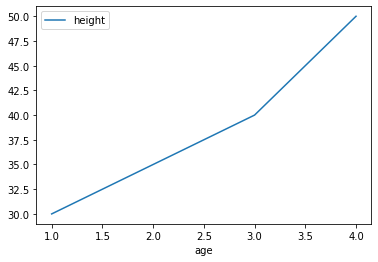

```python
small_df = pd.read_table('../downloads/Orange_1.tsv')
small_df.plot(x='age', y='height')
```

#### Plotting

What if no plot shows up?

```
%pylab inline   # jupyter notebooks
```

or

```
import matplotlib.plot as plt

plt.show()
```

#### Plotting - many trees

- Plot a bar chart

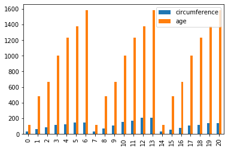

```python
df[['circumference', 'age']].plot(kind='bar')
```

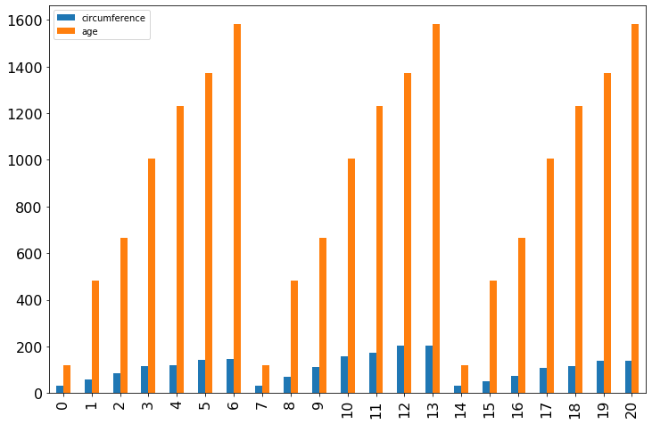

```python
df[['circumference', 'age']].plot(kind='bar', figsize=(12, 8), fontsize=16)
```

#### Scatterplot

```
df.plot(kind="scatter", x="column_name", y="other_column_name")
```

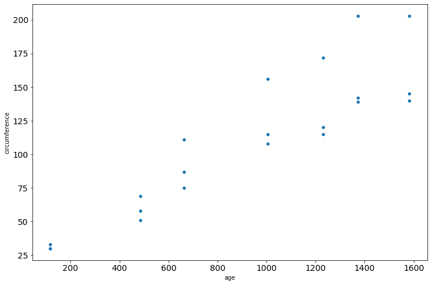

```python
df.plot(kind='scatter', x='age', y='circumference',
        figsize=(12, 8), fontsize=14)
```

#### Line plot

```
dataframe.plot(kind="line", x=..., y=...)
```

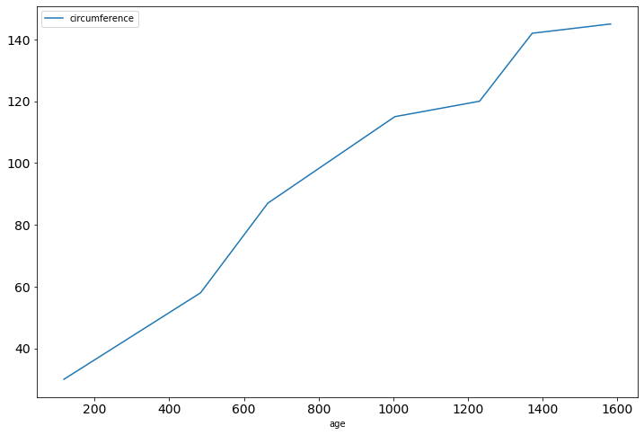

```python
tree1 = df[df['Tree'] == 1]
tree1.plot(x='age', y='circumference',
           fontsize=14, figsize=(12,8))
```

#### Line plot of all trees

- Let's plot all the trees

  ```
  dataframe.plot(kind="line", x="..", y="...")
  ```

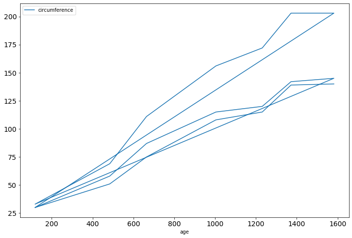

```python
df.plot(kind='line', x='age', y='circumference',
        figsize=(12, 8), fontsize=14)
```

:(

```
tree_names: [1 2 3]
```

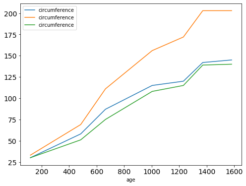

```python
import matplotlib.pyplot as plt
fig, ax = plt.subplots()

tree_names = df['Tree'].unique()
print('tree_names:', tree_names)

for tree_name in tree_names:
    sub_df = df[df['Tree'] == tree_name]
    sub_df.plot(x='age', y='circumference', kind='line',
                ax=ax, fontsize=14, figsize=(8,6))
```

### Exercise 5

- Read the `Orange_1.tsv`
  - Print the height column
  - Print the data for the tree at age 2
  - Find the maximum circumference
  - What tree reached that circumference, and how old was it at that time?
- Use Pandas to read IMDB
  - Explore it by making graphs
- Extra exercises:
  - Read the pandas documentation :)
  - Look at seaborn for a more feature-rich plotting lib